# Guessing, if there is a Heart Attack or not

## The Data Visualization

$$~$$

In this subsection we want to describe graphically the dataset that we are analyzing to have a first taste of what is the better model to use in this case, we want to show below some interesting plots

$$~$$

### The visualization using PCA

$$~$$

PCA is a particular tool that allows us to show the behaviour of the patients (treated as points in this space) of our data. We see in this way which are the patients more similar to each other

$$~$$

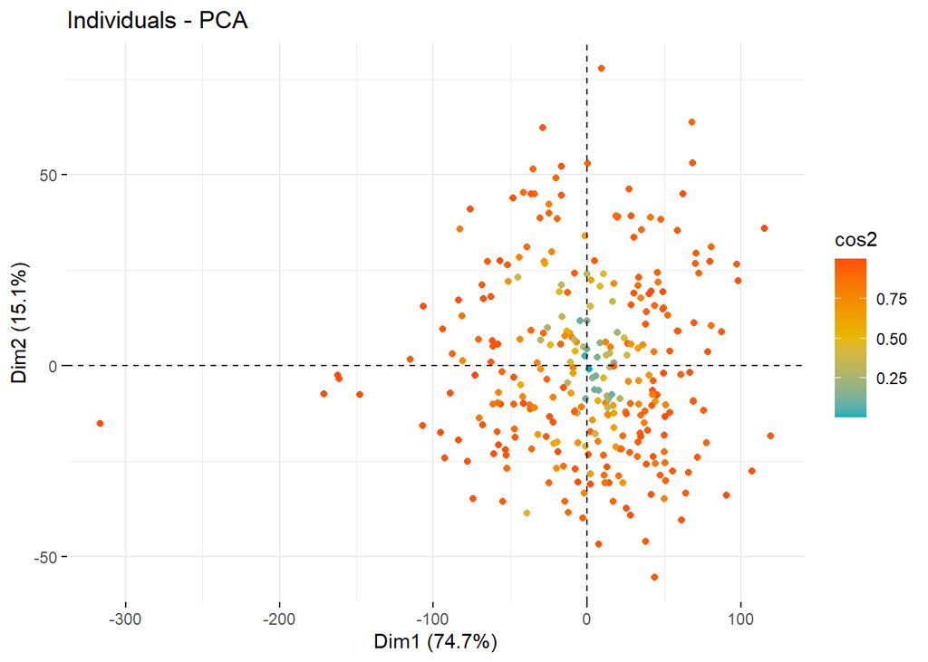

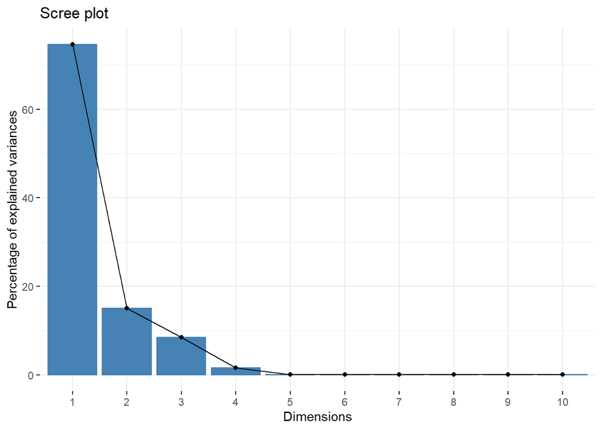

$$~$$

Its normal to denote that there could be some losses on this representation due to the amount of features that we want to consider.

$$~$$

## The Categorical Data

$$~$$

Here, we want to analyze the percentages of the categorical data:

$$~$$

[interactive chart not shown]

$$~$$